# MAV105 Session 3 - Installing and Introduction to R

2021

# 1 Installing R and RStudio

**Hi everyone!**

In this course you will learn to use `R` and `Rstudio` to analyse genetic data.  
Usually we are in the computer room but this year we will be teaching you online.  
This means that you have to do the exercises on your own computer and will need to install the appropriate software and packages. We have provided full installations instructions below, feel free to install all the software *and* packages listed before we meet and we can spend more time on working and coding in R when we meet. If you already have `R` and `Rstudio` installed, make sure that you have an R version above 4.0 (newest version of R is R 4.0.4, Lost Library Books) and RStudio above 1.3 (newest version of Rstudio is RStudio 1.4.1106)

You can check your R version by typing:

```
R.version.string
```

See you soon!

## 1.1 R and RStudio

**R**

[figure not shown]

R is a programming language, most often used for statistical computing, and comes with it’s own free software environment. When you download R you also get a graphical user interface (GUI), but in large it’s more similar to a command line interface. This means that there are not many buttons to click and you have to do almost everything in code. In R, you can write a program and run the code independently of any other computer program.

**Rstudio**

[figure not shown]

Rstudio integrated development environment (IDE) that makes R easier to use and is more similar to other software you might be more familiar with. It includes a code editor, debugging, visualization tools, workspace management and much more. Believe me, you want Rstudio in order to have a nice R experience.

**R and RStudio are not separate versions of the same program, and cannot be substituted for one another. R may be used without RStudio, but RStudio may not be used without R. RStudio must be used alongside R in order to properly function.**

## 1.2 Packages

R packages are collections of functions and data sets developed by users (yes you too can create your own package). A package is actually a good way to organize your own work and, if you want to, share it with others. Typically, a package will include code (not only R code), documentation for the package and the functions inside, some tests to check everything works as it should, and data sets. They increase the power of R by improving existing base R functionalities, or by adding new ones.

**At the end of this document you will find a full list of packages to install with instructions**

### 1.2.1 Special mentions

**`Tidyverse`**

The Tidyverse provides a set of packages that augment R capabilities and share an underlying design, philosophy, grammar, and data structures. Basically it’s a different way to work within R that more and more people are using. Most people find that is more intuitive that base R and it’s often easier to read for others, as well as yourself when you come back to old code you wrote.

We only have limited time and will just briefly introduce some small parts of Tidyverse but we really hope that you will continue exploring it on your own.  
We highly recommend [this free book](https://r4ds.had.co.nz/) written by the Hadley Wickham, one of the creators of Tidyverse. It’s a general good introduction for beginners but also veterans who want to learn the tidy way.

**`Swirl`**

Another useful tool if you want to learn more R on your own is the package called `Swirl`.  
`Swirl` is an interactive package with different courses to teach you R programming in R.  
We won’t have time to work through the lessons in class, but it’s easy to use on your own too. You can even get started before we meet if you want a head start  
Note: swirl mainly uses base R and not tidyverse

If you want to start with swirl just open Rstudio and type the following code:

```
# This loads the package
library(swirl)

# This installs the course "R Programming"
swirl::install_course("R Programming")

# This starts swirl, follow the instructions and have fun coding!
Swirl()
```

## 1.3 Mac Users

### 1.3.1 Installing R

1. Open an internet browser and go to https://www.r-project.org
2. Click the “download R” link in the middle of the page under “Getting Started.”
3. Select a CRAN location (a mirror site, e.g. Sweden or Denmark) and click the corresponding link.
4. Click on the “Download R for (Mac) OS X” link at the top of the page.
5. Click on the file containing the latest version of R “R-4.0.4.pkg”
6. Save the .pkg file, double-click it to open, and follow the installation instructions.
7. Now that R is installed, you need to download and install RStudio.

### 1.3.2 Installing RStudio

1. Go to https://rstudio.com/products/rstudio/download/
2. Under the free version of Rstudio Desktop click “Download”
3. Click on the version recommended for your system. Save the .dmg file on your computer, double-click it to open, and then drag and drop it to your applications folder.

### 1.3.3 Installing packages

How you can install a package will depend on where it is located. So, for publicly available packages the most common way is to use the CRAN repository, then you just need the name of the package and use the command `install.packages("package")`. Most of our packages are located there. But there are many more packages in other repositories such as GitHub, BitBucket or BiocManager. Just remember that some of the packages on these repositories might still be under development and don’t undergo the same frequent testing as the once you find on CRAN. We will install one package from BiocManager.

**Install the following packages**

```
install.packages("swirl")
install.packages("ape")
install.packages("phangorn")
install.packages("seqinr")
install.packages("BiocManager")
BiocManager::install("msa")
install.packages("tidyverse")
install.packages("grDevices")
install.packages("maps")
```

You can check that all packages have been installed successfully by running the following code. It should list all the packages and say `TRUE` if they work and `FALSE` if something went wrong.

```
pkg_list <- c("swirl", "ape", "phangorn", "seqinr", "BiocManager", "msa", "tidyverse", "grDevices", "maps")

sapply(pkg_list, require, character.only=TRUE)
```

```
##       swirl         ape    phangorn      seqinr BiocManager         msa
##        TRUE        TRUE        TRUE        TRUE        TRUE        TRUE
##   tidyverse   grDevices        maps
##        TRUE        TRUE        TRUE
```

If it says `FALSE` try and install the package in question again, if it still doesn’t work come for the R help session on the 18th of March and we will help you get set up.

## 1.4 Windows Users

### 1.4.1 Installing R:

1. Open an internet browser and go to https://www.r-project.org
2. Click the “download R link in the middle of the page under”Getting Started."
3. Select a CRAN location (a mirror site, e.g. Sweden or Denmark) and click the corresponding link.
4. Click on the “Download R for Windows” link at the top of the page.
5. Click on the “install R for the first time” link at the top of the page.
6. Click “Download R 4.0.4 for Windows” and save the executable file somewhere on your computer. Run the .exe file by double clicking it and follow the installation instructions.
7. Now that R is installed, you need to download and install RStudio.

### 1.4.2 Installing RStudio

1. Go to https://rstudio.com/products/rstudio/download/
2. Under the free version of Rstudio Desktop click “Download”
3. Click on the version recommended for your system, and save the executable file. Run the .exe file by double clicking on it and follow the installation instructions.

### 1.4.3 Installing packages

How you can install a package will depend on where it is located. So, for publicly available packages the most common way is to use the CRAN repository, then you just need the name of the package and use the command `install.packages("package")`. Most of our packages are located there. But there are many more packages in other repositories such as GitHub, BitBucket or BiocManager. Just remember that some of the packages on these repositories might still be under development and don’t undergo the same frequent testing as the once you find on CRAN. We will install one package from BiocManager.

If your computer OS is windows, you might need to install the software “Rtools” in order to install the packages that do not come from CRAN. You can download it from the following website https://cran.r-project.org/bin/windows/Rtools/. You should install the version rtools40-x86_64.exe or above.

**Install the following packages**

```
install.packages("swirl")
install.packages("ape")
install.packages("phangorn")
install.packages("seqinr")
install.packages("BiocManager")
BiocManager::install("msa")
install.packages("tidyverse")
install.packages("grDevices")
install.packages("maps")
```

You can check that all packages have been installed successfully by running the following code. It should list all the packages and say `TRUE` if they work and `FALSE` if something went wrong.

```
pkg_list <- c("swirl", "ape", "phangorn", "seqinr", "BiocManager", "msa", "tidyverse", "grDevices", "maps")

sapply(pkg_list, require, character.only=TRUE)
```

```
##       swirl         ape    phangorn      seqinr BiocManager         msa
##        TRUE        TRUE        TRUE        TRUE        TRUE        TRUE
##   tidyverse   grDevices        maps
##        TRUE        TRUE        TRUE
```

If it says `FALSE` try and install the package in question again, if it still doesn’t work come for the R help session on the 18th of March and we will help you get set up.

## 1.5 Linux Users

**(Ubuntu 19.04/18.04/16.04 / Debian / Linux Mint distribution)**

### 1.5.1 Update system:

```
sudo apt update
sudo apt upgrade
```

### 1.5.2 Installing R:

```
sudo apt install r-base
sudo apt-get install r-base-dev
```

### 1.5.3 Installing RStudio

1. Go to https://rstudio.com/products/rstudio/download/
2. Under the free version of Rstudio Desktop click “Download”
3. Click on the version recommended for your system, and save the .deb package.

Run the following two lines after adding the path to your downloaded file.

```
sudo apt-get install gdebi
sudo gdebi path_to_file/file_name.deb
```

### 1.5.4 Installing packages

How you can install a package will depend on where it is located. So, for publicly available packages the most common way is to use the CRAN repository, then you just need the name of the package and use the command `install.packages("package")`. Most of our packages are located there. But there are many more packages in other repositories such as GitHub, BitBucket or BiocManager. Just remember that some of the packages on these repositories might still be under development and don’t undergo the same frequent testing as the once you find on CRAN. We will install one package from BiocManager.

If your computer OS is windows, you might need to install the software “Rtools” in order to install the packages that do not come from CRAN. You can download it from the following website https://cran.r-project.org/bin/windows/Rtools/. You should install the version rtools40-x86_64.exe or above.

**Install the following packages**

```
install.packages("swirl")
install.packages("ape")
install.packages("phangorn")
install.packages("seqinr")
install.packages("BiocManager")
BiocManager::install("msa")
install.packages("tidyverse")
install.packages("grDevices")
install.packages("maps")
```

You can check that all packages have been installed successfully by running the following code. It should list all the packages and say `TRUE` if they work and `FALSE` if something went wrong.

```
pkg_list <- c("swirl", "ape", "phangorn", "seqinr", "BiocManager", "msa", "tidyverse", "grDevices", "maps")

sapply(pkg_list, require, character.only=TRUE)
```

```
##       swirl         ape    phangorn      seqinr BiocManager         msa
##        TRUE        TRUE        TRUE        TRUE        TRUE        TRUE
##   tidyverse   grDevices        maps
##        TRUE        TRUE        TRUE
```

If it says `FALSE` try and install the package in question again, if it still doesn’t work come for the R help session on the 18th of March and we will help you get set up.

# 2 Introduction to R

Before going further, make sure you have a recent version of R. You should have anything above ≥ 4.0. You can check your R version by typing:

```
R.version.string
```

## 2.1 R and Rstudio basics

First we are going to start with a quick introduction to R, Rstudio, workspace and working directory based on tutorial created by the University of British Columbia. It gives some quick insights into R and the Rstudio working environment. [You can find the original content here](https://www.stat.ubc.ca/~jenny/STAT545A/block01_basicsWorkspaceWorkingDirProject.html#r-basics-workspace-and-working-directory-rstudio-projects)

Launch RStudio/R.

Notice the default panes:

- Console (entire left)
- Environment/History (tabbed in upper right)
- Files/Plots/Packages/Help (tabbed in lower right)

FYI: you can change the default location of the panes, among many other things: [Customizing RStudio](https://support.rstudio.com/hc/en-us/articles/200549016-Customizing-RStudio).

Go into the Console, where we interact with the live R process.

Make an assignment and then inspect the object you just created:

```r
x <- 3 * 4
x
```

```
## [1] 12
```

All R statements where you create objects – “assignments” – have this form:

```r
objectName <- value
```

and in my head I hear, e.g., “x gets 12”.

You will make lots of assignments and the operator `<-` is a pain to type. Don’t be lazy and use `=`, although it would work, because it will just sow confusion later. Instead, utilize RStudio’s keyboard shortcut: Alt + - (the minus sign).

Notice that RStudio automatically surrounds `<-` with spaces, which demonstrates a useful code formatting practice. Code is miserable to read on a good day. Give your eyes a break and use spaces.

RStudio offers many handy [keyboard shortcuts][https://support.rstudio.com/hc/en-us/articles/200711853-Keyboard-Shortcuts]. Also, Alt+Shift+K brings up a keyboard shortcut reference card.

Object names cannot start with a digit and cannot contain certain other characters such as a comma or a space. You will be wise to adopt a [convention for demarcating words][https://journal.r-project.org/archive/2012-2/RJournal_2012-2_Baaaath.pdf] in names.

```
i_use_snake_case
other.people.use.periods
evenOthersUseCamelCase
```

Make another assignment:

```r
this_is_a_really_long_name <- 2.5
```

To inspect this, try out RStudio’s completion facility: type the first few characters, press TAB, add characters until you disambiguate, then press return.

Make another assignment:

```r
jenny_rocks <- 2 ^ 3
```

Let’s try to inspect:

```r
jennyrocks
```

```
## Error in eval(expr, envir, enclos): object 'jennyrocks' not found
```

```r
jeny_rocks
```

```
## Error in eval(expr, envir, enclos): object 'jeny_rocks' not found
```

Implicit contract with the computer / scripting language: Computer will do tedious computation for you. In return, you will be completely precise in your instructions. **Typos matter. Case matters. Get better at typing.**

R has a mind-blowing collection of built-in functions that are accessed like so:

```r
functionName(arg1 = val1, arg2 = val2, and so on)
```

Let’s try using `seq()` which makes regular sequences of numbers and, while we’re at it, demo more helpful features of RStudio.

Type `se` and hit TAB. A pop up shows you possible completions. Specify `seq()` by typing more to disambiguate or using the up/down arrows to select. Notice the floating tool-tip-type help that pops up, reminding you of a function’s arguments. If you want even more help, press F1 as directed to get the full documentation in the help tab of the lower right pane. Now open the parentheses and notice the automatic addition of the closing parenthesis and the placement of cursor in the middle. Type the arguments `1, 10` and hit return. RStudio also exits the parenthetical expression for you. IDEs are great.

```r
seq(1, 10)
```

```
##  [1]  1  2  3  4  5  6  7  8  9 10
```

The above also demonstrates something about how R resolves function arguments. You can always specify in `name = value` form. But if you do not, R attempts to resolve by position. So above, it is assumed that we want a sequence `from = 1` that goes `to = 10`. Since we didn’t specify step size, the default value of `by` in the function definition is used, which ends up being 1 in this case. For functions I call often, I might use this resolve by position for the first argument or maybe the first two. After that, I always use `name = value`.

Make this assignment and notice similar help with quotation marks.

```r
yo <- "hello world"
```

If you just make an assignment, you don’t get to see the value, so then you’re tempted to immediately inspect.

```r
y <- seq(1, 10)
y
```

```
##  [1]  1  2  3  4  5  6  7  8  9 10
```

This common action can be shortened by surrounding the assignment with parentheses, which causes assignment and “print to screen” to happen.

```r
(y <- seq(1, 10))
```

```
##  [1]  1  2  3  4  5  6  7  8  9 10
```

Not all functions have (or require) arguments:

```r
date()
```

```
## [1] "Tue Mar  9 11:26:55 2021"
```

Now look at your workspace – in the upper right pane. The workspace is where user-defined objects accumulate. You can also get a listing of these objects with commands:

```r
objects()
```

```
## [1] "jenny_rocks"                "pkg_list"
## [3] "this_is_a_really_long_name" "x"
## [5] "y"                          "yo"
```

```r
ls()
```

```
## [1] "jenny_rocks"                "pkg_list"
## [3] "this_is_a_really_long_name" "x"
## [5] "y"                          "yo"
```

If you want to remove the object named `y`, you can do this:

```r
rm(y)
```

To remove everything:

```r
rm(list = ls())
```

or click the broom in RStudio’s Environment pane.

## 2.2 Workspace and working directory

One day you will need to quit R, go do something else and return to your analysis later.

One day you will have multiple analyses going that use R and you want to keep them separate.

One day you will need to bring data from the outside world into R and send numerical results and figures from R back out into the world.

To handle these real life situations, you need to make two decisions:

- What about your analysis is “real”, i.e. will you save it as your lasting record of what happened?
- Where does your analysis “live”?

### 2.2.1 Workspace, `.RData`

As a beginning R user, it’s OK to consider your workspace “real”. *Very soon*, I urge you to evolve to the next level, where you consider your saved R scripts as “real”. (In either case, of course the input data is very much real and requires preservation!) With the input data and the R code you used, you can reproduce *everything*. You can make your analysis fancier. You can get to the bottom of puzzling results and discover and fix bugs in your code. You can reuse the code to conduct similar analyses in new projects. You can remake a figure with different aspect ratio or save is as TIFF instead of PDF. You are ready to take questions. You are ready for the future.

If you regard your workspace as “real” (saving and reloading all the time), if you need to redo analysis … you’re going to either redo a lot of typing (making mistakes all the way) or will have to mine your R history for the commands you used. Rather than becoming an expert on managing the R history, a better use of your time and psychic energy is to keep your “good” R code in a script for future reuse.

Because it can be useful sometimes, note the commands you’ve recently run appear in the History pane.

But you don’t have to choose right now and the two strategies are not incompatible. Let’s demo the save / reload the workspace approach.

Upon quitting R, you have to decide if you want to save your workspace, for potential restoration the next time you launch R. Depending on your set up, R or your IDE, e.g. RStudio, will probably prompt you to make this decision.

Quit R/RStudio, either from the menu, using a keyboard shortcut, or by typing `q()` in the Console. You’ll get a prompt like this:

> Save workspace image to ~/.Rdata?

*Note where the workspace image is to be saved* and then click “Save”.

Using your favourite method, visit the directory (folder) where image was saved and verify there is a file named `.RData`. You will also see a file `.Rhistory`, holding the commands submitted in your recent session.

Restart RStudio. In the Console you will see a line like this:

```
[Workspace loaded from ~/.RData]
```

indicating that your workspace has been restored. Look in the Workspace pane and you’ll see the same objects as before. In the History tab of the same pane, you should also see your command history. You’re back in business. This way of starting and stopping analytical work will not serve you well for long but it’s a start.

Once/if you get to that point that you don’t want to save your workspace `.RData`, there are options available in RStudio to disable the loading of `.RData` and permanently suppress the prompt on exit to save the workspace (go to *Tools > Options > General*).

### 2.2.2 Working directory

Any process running on your computer has a notion of its “working directory”. In R, this is where R will look, by default, for files you ask it to load. It also where, by default, any files you write to disk will go. Chances are your current working directory is the directory we inspected above, i.e. the one where RStudio wanted to save the workspace.

You can explicitly check your working directory with:

```r
getwd()
```

It is also displayed at the top of the RStudio console.

As a beginning R user, it’s OK let your home directory or any other weird directory on your computer be R’s working directory. *Very soon*, I urge you to evolve to the next level, where you organize your analytical projects into directories and, when working on project A, set R’s working directory to the associated directory.

**Although I do not recommend it**, in case you’re curious, you can set R’s working directory at the command line like so:

```r
setwd("~/myCoolProject")
```

**Although I do not recommend it**, you can also use RStudio’s Files pane to navigate to a directory and then set it as working directory from the menu: *Session > Set Working Directory > To Files Pane Location*. (You’ll see even more options there). Or within the Files pane, choose “More” and “Set As Working Directory”.

But there’s a better way. A way that also puts you on the path to managing your R work like an expert.

## 2.3 RStudio projects

Keeping all the files associated with a project organized together – input data, R scripts, analytical results, figures – is such a wise and common practice that RStudio has built-in support for this via its [*projects*](https://support.rstudio.com/hc/en-us/articles/200526207-Using-Projects).

Let’s make one to use for the rest of this class. Do this: *File > New Project > New Directory*. The directory name you choose here will be the project name. Call it whatever you want (or follow me for convenience).

[figure not shown]

I created a directory and, therefore RStudio project, called `MAV105_R` in my `Documents` directory, FYI.

Now check that the “home” directory for your project is the working directory of our current R process:

```
getwd()
```

Let’s enter a few commands in the Console, as if we are just beginning a project:

```r
a <- 2
b <- -3
sig_sq <- 0.5
x <- runif(40)
y <- a + b * x + rnorm(40, sd = sqrt(sig_sq))
(avg_x <- mean(x))
```

```
## [1] 0.4575584
```

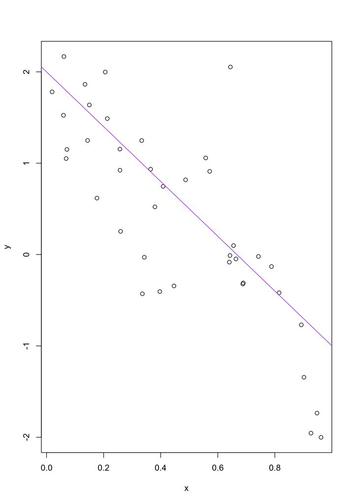

```r
write(avg_x, "avg_x.txt")
plot(x, y)
abline(a, b, col = "purple")
```

```r
dev.print(pdf, "toy_line_plot.pdf")
```

Let’s say this is a good start of an analysis and your ready to start preserving the logic and code. Visit the History tab of the upper right pane. Select these commands. Click “To Source”. Now you have a new pane containing an R script. Click on the floppy disk to save. Give it a name ending in `.R` or `.r`, I used `toy-line.r` and note that, by default, it will go in the directory associated with your project. Close the script.

Inspect the folder associated with your project. Take a look at the PDF in an external viewer. Then open the R script you just created by double clicking on it in your project folder. Now that you know what the code did you can add some comments. Comments a preceded by a # symbol and tells R that what comes after the # is simply plain text and should not be run as code. Try adding some useful comments to your R script so that if you come back to it in a few weeks or so you can remember what you did.

```
# Assign variables
a <- 2
b <- -3
sig_sq <- 0.5

# Create fake X values
x <- runif(40)

# Create fake Y values
y <- a + b * x + rnorm(40, sd = sqrt(sig_sq))

#
(avg_x <- mean(x))
write(avg_x, "avg_x.txt")

#
plot(x, y)
abline(a, b, col = "purple")

#
dev.print(pdf, "toy_line_plot.pdf")
```

## 2.4 Packages

Packages are collections of R functions, data, and compiled code in a well-defined format. The directory where packages are stored is called the library. R comes with a standard set of packages. Others are available for download and installation. Once installed, they have to be loaded into the session with `library()` to be used.

You can try and load a package like this

```r
library(swirl)
```

If at some point you are unsure about the version of the package, you can check it using:

```r
packageDescription("swirl", fields = "Version")
```

```
## [1] "2.4.5"
```

## 2.5 Getting help

There are several ways of getting information about R in general. The function `help.search` is used to look for help on any given topic. For instance:

```r
help.search("alignment")
```

replies with a list of functions from different packages. To get help for a given function, use `help()` or `?` followed by the name of the function you are interested in.

```r
help(readDNAStringSet)
?readDNAStringSet
```

will open up the help of the function. At the end of a manual page, an ‘example’ section often shows how to use a function.

If the function you are interested in is part of a package you haven’t loaded into your working environment R will tell you

`No documentation for ‘package_name’ in specified packages and libraries: you could try ‘??package_name’`

in which case you simply use `??`

```r
??readDNAStringSet
```

## 2.6 Sample Data

R comes with a number of sample data sets that you can experiment with. Type `data( )` to see the available data sets. The results will depend on which packages you have loaded as many packages have their own sample data you can explore. Type `help(datasetname)` for details on a specific sample data set.

## 2.7 Tips, tricks and other stuff

- `alt` + `-` to create <- (on Mac it might be `option` + `-`)
- press tab for auto completion
- use up arrow to recycle through recent commands
- `help()` or `?`
- R iS cAsE SeNsAtIvE
- use "" to let R know what is a string of text like “this”
- if you want to save your code you can write everything inside a `script`
- to execute from a script press PC- `control` + `enter` Mac- `command` + `enter`

**If you get an error do the following**

1. Check if your spelling correct.
2. Ask someone else to check if your spelling is correct, 4 eyes are better than 2
3. Are you in the right directory? `getwd()`
4. Is the file in the right directory and is your path to the file correct `list.dirs()`?
5. Check the `help()` manual for your function
6. Copy the error message and google it, your unlikely to be the first with this error
7. Are you *really* sure the spelling is correct?
8. Ask one of the instructors for help.

Comments start with one or more `#` symbols. Use them. RStudio helps you (de)comment selected lines with Ctrl+Shift+C (Windows and Linux) or Command+Shift+C (Mac).

This workflow will serve you well in the future:

- Create an RStudio project for an analytical project
- Keep inputs there
- Keep scripts there; edit them, run them in bits or as a whole from there
- Keep outputs there

[figure not shown]